# Wine Tasting

Chuyue Xie

2022-12-02

[figure not shown]

# Background

In the United States of America, the 100-pt rating system is commonly used to indicate the production quality and typicity (how well the wine’s trait represent the style and region it’s from) of wine. Wine Enthusiast offers reviews for wine with a score range from 80 to 100 points.

**Wine Enthusiast’s 100-point wine-scoring scale**

- 98–100 – Classic
- 94–97 – Superb
- 90–93 – Excellent
- 87–89 – Very good
- 83–86 – Good
- 80–82 – Acceptable

With around **130k** wine reviews published on Wine Enthusiast, I hope to explore the data and address the following questions:

1. Which province offers wine of highest average price?
2. Which province had the most reviews? Which varieties had the most reviews in this province?
3. Can ratings in points help estimate price?
4. What are some of the most common terms used in positive reviews? Negative reviews?

# Preprocessing Stage

The first step is to prepare the data for analysis.

### Clean up environment and load packages

The packages used are *tidyverse* and *wordcloud*.

```r
# clean up the RStudio environment
rm(list = ls())

# load all packages here: `tidyverse`, `lubridate`, and all others used
library('tidyverse')#tidying data
library('wordcloud')#work with word cloud
```

### Data Intake

The data was found on and downloaded from [Mavenan Alytics](https://www.mavenanalytics.io/data-playground?page=4&pageSize=5&tags=5qOZ7YrIptmdsL081BSli) (Source: Zack Thoutt, scraped from WineEnthusiast). The codes below sets up data from the downloaded csv files.

```r
### Load wine data from wine_data.csv
Wine <- read_csv("wine_data.csv") #full data with ~130k rows
```

### Data Inspection

This dataset has 129,971 rows and 14 variables (3 numerical variables and 11 categorical variables). Each row of the data appears to be a case of review for wine. There are several NA’s in the fields and the maximum price is a lot larger than 75% quantile, which suggests the necessity of **data cleaning stage**.

```r
Wine %>%
  head(3) #the glimpse function will present the columns down the page and rows across

Wine %>%
  summary() #the summary function will summarize the table
```

### Data Cleaning

In the following parts, missing values, duplicated values, and extreme values in data are fixed or removed.

#### Missing Values

First, the missing value problem is evaluated and dealt with. According to the analysis, 107584 rows and 9 columns contain missing values, which is about **83%** of the data. Hence, it’s not rational to delete all data contain missing values. The variables that are missing more than 10% are: *designation*, *taster_name*, *taster_twitter_handle*, *region_1*, and *region_2.*

- Since the “*region_1*”, “*region_2*”, and “*taster_twitter_handle*” are not related to our analysis and they contain many missing values, these **three columns will be dropped**.
- For “*designation*” and “*taster_name*”, since removing them will result in significant data loss, the missing values will be **filled as “Unknown”**.
- Moreover, for variables with limited missing data, the **rows that contain missing values will be dropped**.

```r
## Only keep relevant cols
Wine <- Wine %>%
  select(-c(region_1, region_2, taster_twitter_handle))

## Define cols we replace NA with 'Unknown'
unk_cols <- c("designation", "taster_name")
## Replace NAs with 'Unknown'
Wine[unk_cols] <- Wine[unk_cols] %>%
  replace_na(list(designation = 'Unknown', taster_name = 'Unknown'))
## Remove the rest rows with missing values
Wine <-
  Wine %>%
  na.omit()
## Double check number of rows with missing values
#sum(rowSums(is.na(Wine)) != 0)
#nrow(Wine)
```

After these steps, we have 120915 rows of data, with is 7% less than original and acceptable.

#### Duplicate Values

Now there are no missing values, let’s check if there are any duplicated values. Since the ids are added afterwards to make each row unique, uniqueness is tested without the *id* column. There are **9378 duplicated rows**, which will be *removed* and new ids will be assigned to the distinct data. As a result, we have 111537 entries of unique data.

```r
## Count duplicated descriptions
Wine %>%
  select(-id) %>%
  duplicated() %>%
  sum()

## Remove duplicate values
Wine <- Wine %>%
  select(-id) %>%
  distinct()

## Re-assign ids
Wine <- Wine %>%
  mutate(id = 1:n())
```

#### Extreme Values

To figure out the distribution of price, histogram of is plotted. The histogram looks extremely right skewed, which make sense because most wine have moderate price and a few of them will be a little more expensive.

```r
hist(Wine$price, main = 'Histogram of Price', xlab = 'Price') #histogram of price
```

[output not shown]

By taking the log transform, the histogram looks much better, but some outliers still seem to exist.

```r
Wine$price_log <- log(Wine$price) #log transform of price
hist(Wine$price_log, main = 'Histogram of log(Price)', xlab = 'log(Price)') #histogram of log(price)
```

[output not shown]

With more research, reviews with extremely high price values seem to be mistakes rather than real expensive wine. Hence, the approach to deal with these extreme values is to **delete** them from the dataset.

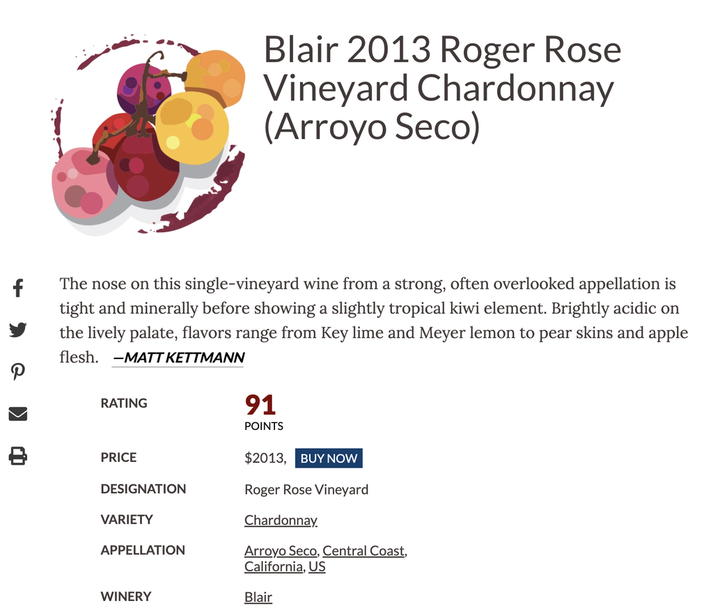

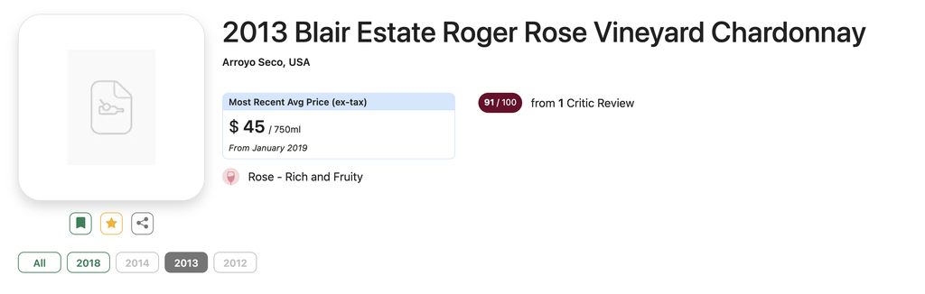

```r
summary(Wine$price_log) #summarise log(price)
iqr = 3.738-2.833 #calculate IQR
Wine <- Wine %>%
  filter(price_log >= 2.833-iqr*2 & price_log <= 3.738+iqr*2) #delete data with extreme price value
```

As a result, we have 111,103 rows of clean data.

```r
Wine %>%
  nrow()
```

# Data Analysis Stage

Now that the data is clean, I will analyze the data and try to answer four questions mentioned above.

### Question 1

Which province offers wine of highest average price?

### Question 2

Which province had the most reviews? Which varieties had the most reviews in this province?

### Question 3

Can ratings in points help estimate price?

By plotting *points* with *log(price)*, the relationship seem approximately linear.

### Question 4

What are some of the most common terms used in positive reviews? Negative reviews?

**Answer**Considering the *Wine Enthusiast’s 100-point wine-scoring scale*, let’s define positive reviews by *points* equal to or higher than 98 and negative reviews by 8 less than or equal to 82.

**Step 1** Define the word count function The first step is to define a function that convert the vector of descriptions into a dataset of the vocabularies used and their frequencies.

**Step 2** Visualize the overall word frequency for reviews

Positive reviews:

Negative reviews:

**Step 3** Clean up the key words list using stop words

**Negative reviews**: While some positive words such as “sweet” and “soft” shows up in negative reviews, “dry”, “bitter”, and “sour” seem to reveal the taste of these wine.

Overall, in positive reviews, the tasters mainly praised on the dark color and great overall quality. On the other hand, tasters usually criticize the bitter, dry, and sour taste of wine in negative reviews.

# Conclusion

The following business insights are drawn based on the analysis:

- Wine from Champagne has the highest average price, if you have limited budget and don’t know the price of wine, try to avoid wine from this province
- Wines from California received the most reviews, especially varieties including Point Noir, Cabernet Sauvignon, and Chardonnay. If you want to try wine that are commonly known and tasted, you may give these wine a try.
- In order to buy wine with “Very Good” quality, you should prepare around $23, and to get a bottle of “Classic” wine, you will need to pay around $92.
- Wine with high ratings usually have dark color and makes taster feel great, while wine with low ratings usually exhibit sour,dry, and bitter taste.